## Introductie

Dit is de handleiding voor de gebruikers van het informatiesysteem Opendata Amsterdam. In de handleiding wordt uitgelegd hoe je de web applicatie Opendata Amsterdam kan gebruiken en wat het voor jou kan betekenen.

In de applicatie zijn er verschillende interactieve visualisaties ter beschikking gesteld, die voor iedereen te gebruiken zijn. Door middel van deze visualisaties kan iedereen over verschillende onderwerpen informatie vinden over Amsterdam.

## Kies een thema

Als je als gebruiker naar de website Opendata Amsterdam gaat dan zal u zien dat er een pagina verschijnt waarop u een thema selectie kan maken. Dit zijn allemaal thema’s die betrekking hebben op de gemeente Amsterdam. Elk verschillend thema heeft een eigenlijk tegel met daarop een tekst en een icoon. De tekst en het icoon geven weer over welk thema het gaat, zoals je kan zien in figuur 1. In de afbeelding hieronder zijn niet alle thema’s weergegeven. Als er op een van de thema tegels geklikt is, dan verschijnt een nieuwe pagina met daarop de map van Amsterdam.

1. Kies een **thema**.
2. **Klik op een tegel** om naar de map te gaan met het geselecteerde thema.

[figure not shown]

Figuur 1

## Kaart van Amsterdam

Nadat er een keuze is gemaakt uit een van de verschillende thema’s, krijg je een pagina te zien met daarop de map van Amsterdam, indicator selectie, level selectie en een mogelijkheid om een jaar te selecteren. Als de gebruiker nog geen selecties heeft gemaakt, dan wordt er niks getoond op de map. Wanneer je als gebruiker een indicator selecteert zal automatisch het level selectie box gevuld worden met mogelijkheden om als gebruiker te selecteren. Om data te kunnen zien op die map moet je een indicator en een level selecteren. Zoals je kan zien in figuur 2 is er een selectie gemaakt en kan je de binnenbranden in 2016 zien van alle buurten in Amsterdam.

[figure not shown]

Figuur 2

**Data weergeven kaart Amsterdam**

1. Klik op de dropdown indicator.
2. **Kies is een indicator** die je wilt bekijken.
3. Klik op de level dropdown.
4. **Kies een level** die je wilt bekijken.
5. De map komt nu tevoorschijn.

**Data weergeven over de jaren heen**  
Voorwaarden: Data weergeven kaart Amsterdam

Verder heb je rechts van de map ook nog een tabel met informatie over de gemaakte selecties. Er is ook een mogelijkheid om op een bepaalde buurt te klikken op de map. Nadat de gebruiker dit gedaan heeft verschijnt er onder de map een grafiek met data over deze buurt, zoals te zien is in figuur 3.

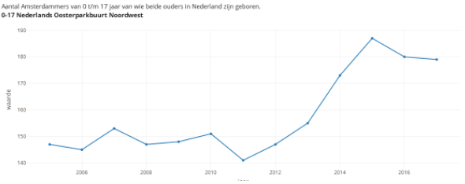

**Data weergeven in grafiek**  
Voorwaarden: Data weergeven kaart Amsterdam

1. **Klik op een buurt** om de grafiek te vullen met data.
2. (Optioneel) Klik op een andere buurt om data te kunnen vergelijken.

## Data viewer

Er is een mogelijkheid om als gebruiker een overzicht te zien van de data die bijvoorbeeld gebruikt is om bepaalde visualisaties te maken. Om naar de data viewer te gaan moet je klikken op de link “Data viewer” bovenin de navigatiebalk. Zoals te zien is in figuur 4, verschijnt er een tabel met data. In deze tabel heb je de optie om te zoeken en sorteren op bepaalde criteria. Daarnaast is er ook een optie om de geselecteerde data te downloaden als een .csv bestand. Dit bestand kan dan bekeken worden met Excel.  
**Data tabel weergeven**

1. Ga naar de **data weergave** tab.
2. Selecteer de **multiselect dropdown indicator(en)**.
3. **Kies één of meerdere indicatoren** waarvan je de data wilt zien.
4. Klik op de knop toon in de tabel.
5. De data wordt nu weergegeven in de tabel.
6. (Optioneel) Gebruik de search bar om specifieke data te vinden.
7. (Optioneel) Gebruik de knoppen onderin om naar de volgende of vorige pagina te gaan.
8. (Optioneel) Verander de hoeveelheid die weergegeven wordt op de pagina door op de show entries dropdown te klikken

**Data tabel downloaden**  
voorwaarden: Data weergeven

1. Klik op de **Download** knop
2. Open het bestand door op het gedownloade bestand te klikken.

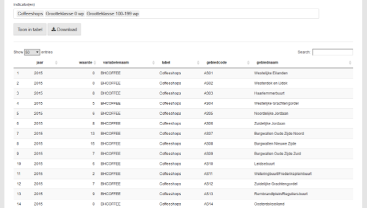

## Leefbaarheid

De gebruiker heeft ook de mogelijkheid om de leefbaarheid van Amsterdam te bekijken. Dit kan gedaan worden door de leefbaarheid tab te selecteren. Deze tab is bovenin de webpagina te vinden. De gebruiker krijgt als eerst een lege map te zien. De gebruiker kan nu een level selecteren, als het level geselecteerd is wordt de map getoond. De data wordt dan door middel van kleuren gevisualiseerd. De betekenis van de kleuren wordt bepaald door de legenda die rechtsboven op de map getoond wordt. Het resultaat hiervan kan bekeken worden in Figuur 5.  
**Leefbaarheid data weergeven**

1. Ga naar het tabblad **leefbaarheid**.
2. Klik op de dropdown level.
3. Kies een level waarvan je de data wilt zien.
4. De data wordt nu weergegeven in de map.

[figure not shown]

Figuur 5

De gebruiker kan op de map klikken om informatie over dat deel te verkrijgen. Deze data wordt weergegeven in bar charts en een overzicht van de cijfers van de vorige jaren. Het geselecteerde gebied wordt in de gebieden vergelijking bar chart gehighlight om de score met de andere gebieden goed te kunnen vergelijken. Daarnaast wordt de score over de jaren heen weergegeven. Ten slotte wordt de afwijking van het gemiddelde voor vijf verschillende categorieën weergegeven in een horizontale bar chart.  
**Data gebied weergeven**

1. Voorwaarden: Leefbaarheid data weergeven
2. **Klik op een gebied** waar je de data van wilt zien.
3. De data wordt nu weergegeven in **de grafieken en tabellen onder de kaart**.

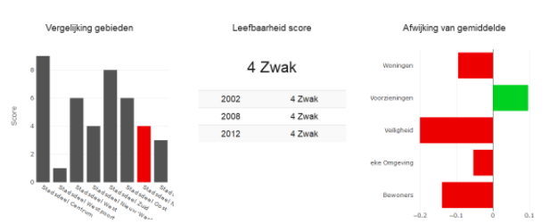

Figuur 6